# Funding Mechanisms

Brandon L. Kramer

3/12/2020

# Step 1: Loading Packages & Ingesting Data

```r
# pulling our list of population
all_pop_terms <- read_csv("population_terms.csv")
us_specific_terms <- all_pop_terms %>% filter(category == "us_specific")
all_pop_terms <- paste(c("\\b(?i)(zqx", all_pop_terms$term, "zqx)\\b"), collapse = "|")
us_specific_terms <- paste(c("\\b(?i)(zqx", us_specific_terms$term, "zqx)\\b"), collapse = "|")
divictionary <- read_csv("diversity_dictionary.csv")

# creating vectors to designate whether
population_data <- text_data %>%
  mutate(abstract = str_to_lower(abstract)) %>%
  mutate(all_pop = ifelse(test = str_detect(string = abstract, pattern = all_pop_terms), yes = 1, no = 0)) %>%
  mutate(race_ethnic = ifelse(test = str_detect(string = abstract, pattern =
         paste(c("\\b(?i)(zqx",na.omit(divictionary$race_ethnicity),us_specific_terms,"zqx)\\b"), collapse = "|")), yes = 1, no = 0)) %>%
  mutate(sex_gender = ifelse(test = str_detect(string = abstract, pattern =
         paste(c("\\b(?i)(zqx", na.omit(divictionary$sex_gender), "zqx)\\b"), collapse = "|")), yes = 1, no = 0))
```

# Step 2: Exploratory Data Analysis of Funders

First, I used these snippets to find the most common funding mechanisms using an n-gram of 3.

```r
text_data %>%
  unnest_tokens(bigram, grant_information, token = "ngrams", n = 3) %>%
  count(bigram) %>%
  arrange(-n)
```

```
## # A tibble: 85,437 x 2
##    bigram            n
##    <chr>         <int>
##  1 <NA>          52827
##  2 niaid nih hhs  9159
##  3 nih hhs r01    6998
##  4 nci nih hhs    5216
##  5 nigms nih hhs  4395
##  6 nhlbi nih hhs  3396
##  7 niddk nih hhs  2299
##  8 nimh nih hhs   1742
##  9 ninds nih hhs  1675
## 10 ncrr nih hhs   1669
## # … with 85,427 more rows
```

Then I unnested all the single tokens.

```r
text_data %>%
  unnest_tokens(word, grant_information) %>%
  count(word) %>%
  filter(!is.na(word)) %>%
  arrange(-n)
```

```
## # A tibble: 27,276 x 2
##    word         n
##    <chr>    <int>
##  1 hhs      42223
##  2 nih      40840
##  3 r01      10662
##  4 niaid     9169
##  5 nci       5227
##  6 nigms     4400
##  7 nhlbi     3398
##  8 research  2885
##  9 niddk     2303
## 10 council   2204
## # … with 27,266 more rows
```

Looks like the HHS, the various divisions of the NIH and the National Research Council are the biggest funders. However, I ultimately took an approach that generated a [more comprehensive list](https://docs.google.com/spreadsheets/d/1Gs-aSgXlnwo8rP3wnpMB0kdrU_VS76aDT3DCiI8OmVU/edit#gid=1403535448) using some online searching of biggest private and public funders across the US, UK and Europe.

# Step 3: Creating a funding dataset with EDA categories

To create this dataset, I recoded all funding information into the following categories: NIH, NSF, HHS, UK or European funders, biotech, foundation, or other funding. I then removed all of the cases missing either funding or abstract information.

```r
funding_mechanisms <- read_csv("funding_information.csv")
nih <- funding_mechanisms %>% filter(logit_category == "US NIH")
nsf <- funding_mechanisms %>% filter(logit_category == "US NSF")
hhs <- funding_mechanisms %>% filter(logit_category == "US HHS")
uk  <- funding_mechanisms %>% filter(logit_category == "UK")
euro <- funding_mechanisms %>% filter(logit_category == "Europe")
biotech <- funding_mechanisms %>% filter(logit_category == "Biotech")
foundation <- funding_mechanisms %>% filter(logit_category == "Foundation")
other <- funding_mechanisms %>% filter(logit_category == "International" |
                                               logit_category == "Africa" |
                                               logit_category == "Asia" |
                                               logit_category == "Australia" |
                                               logit_category == "Americas")

nih <- paste(c("\\b(?i)(zcx", nih$funder, nih$abbreviation, "zxc)\\b"), collapse = "|")
nsf <- paste(c("\\b(?i)(zcx", nsf$funder, nsf$abbreviation, "zxc)\\b"), collapse = "|")
hhs <- paste(c("\\b(?i)(zcx", hhs$funder, hhs$abbreviation, "zxc)\\b"), collapse = "|")
uk <- paste(c("\\b(?i)(zcx", uk$funder, uk$abbreviation, "zxc)\\b"), collapse = "|")
euro <- paste(c("\\b(?i)(zcx", euro$funder, euro$abbreviation, "zxc)\\b"), collapse = "|")
biotech <- paste(c("\\b(?i)(zcx", biotech$funder, biotech$abbreviation, "zxc)\\b"), collapse = "|")
foundation <- paste(c("\\b(?i)(zcx", foundation$funder, foundation$abbreviation, "zxc)\\b"), collapse = "|")
university <- paste(c("\\b(?i)(zcx|university|college|univ.|zxc)\\b"), collapse = "|")
other <- paste(c("\\b(?i)(zcx", other$funder, other$abbreviation, "zxc)\\b"), collapse = "|")

# creating vectors to designate whether
funding_data <- population_data %>%
  drop_na(abstract, grant_information) %>%
  mutate(race_ethnic = as.factor(race_ethnic),
         sex_gender = as.factor(sex_gender),
         all_pop = as.factor(all_pop)) %>%
  mutate(nih = ifelse(test = str_detect(string = grant_information,
                       pattern = nih), yes = 1, no = 0)) %>%
  mutate(nsf = ifelse(test = str_detect(string = grant_information,
                       pattern = nsf), yes = 1, no = 0)) %>%
  mutate(hhs = ifelse(test = str_detect(string = grant_information,
                       pattern = hhs), yes = 1, no = 0)) %>%
  mutate(uk = ifelse(test = str_detect(string = grant_information,
                       pattern = uk), yes = 1, no = 0)) %>%
  mutate(euro = ifelse(test = str_detect(string = grant_information,
                       pattern = euro), yes = 1, no = 0)) %>%
  mutate(biotech = ifelse(test = str_detect(string = grant_information,
                       pattern = biotech), yes = 1, no = 0)) %>%
  mutate(foundation = ifelse(test = str_detect(string = grant_information,
                       pattern = foundation), yes = 1, no = 0)) %>%
  mutate(university = ifelse(test = str_detect(string = grant_information,
                       pattern = university), yes = 1, no = 0)) %>%
  mutate(other = ifelse(test = str_detect(string = grant_information,
                       pattern = other), yes = 1, no = 0)) %>%
  select(abstract, year, grant_information, all_pop, race_ethnic, sex_gender,
         nih, nsf, hhs, euro, uk, biotech, foundation, university, other) %>%
  filter(year > 1993)
```

# Step 4: Dataset Descriptives

Let’s check how many cases we have left (n = 13,768)

```r
funding_data %>%
  count()
```

```
## # A tibble: 1 x 1
##       n
##   <int>
## 1 13768
```

And see that breakdown by year (after 1993).

```r
funding_data %>%
  count(year)
```

```
## # A tibble: 24 x 2
##     year     n
##    <dbl> <int>
##  1  1994   126
##  2  1995   149
##  3  1996   178
##  4  1997   213
##  5  1998   194
##  6  1999   216
##  7  2000   243
##  8  2001   258
##  9  2002   299
## 10  2003   303
## # … with 14 more rows
```

We also need to check how many cases we have for each outcome variable to make sure the classes don’t have bias (i.e. they need to be about the same).

```r
table(funding_data$race_ethnic)
```

```
##
##     0     1
## 12480  1288
```

```r
table(funding_data$sex_gender)
```

```
##
##     0     1
## 12300  1468
```

```r
table(funding_data$all_pop)
```

```
##
##    0    1
## 9077 4691
```

Since these outcomes have bias, we will need to create training sets that sample equally from both sides to run each model.

Before doing that, let’s check to see if our predictor variables have enough cases…

```r
table(funding_data$nih)
```

```
##
##     0     1
##  2823 10945
```

```r
table(funding_data$nsf) # only 23
```

```
##
##     0     1
## 13745    23
```

```r
table(funding_data$hhs)
```

```
##
##     0     1
##  2437 11331
```

```r
table(funding_data$euro) # only 144
```

```
##
##     0     1
## 13624   144
```

```r
table(funding_data$uk)
```

```
##
##     0     1
## 12509  1259
```

```r
table(funding_data$biotech) #only 2
```

```
##
##     0     1
## 13766     2
```

```r
table(funding_data$foundation)
```

```
##
##     0     1
## 12195  1573
```

```r
table(funding_data$university) # only 10
```

```
##
##     0     1
## 13758    10
```

```r
table(funding_data$other)
```

```
##
##     0     1
## 13295   473
```

Looks like we cannot really use NSF funding, biotech funding or university funding since those totals are so low. Those low totals should not be that surprising since NSF funding is not usually allocated to biomedical research, biotech companies ususally invest in private research and are motivated to conceal their funding, and university funding is not all that common for biomedical research either.

# Step 5: Race/Ethnicity Model

Next, we need to create a training dataset to make sure we don’t have tons of bias in our outcome variable.

```r
# Create Training Data
input_ones <- funding_data[which(funding_data$race_ethnic == 1), ]  # all 1's
input_zeros <- funding_data[which(funding_data$race_ethnic == 0), ]  # all 0's
set.seed(100)  # for repeatability of samples
input_ones_training_rows <- sample(1:nrow(input_ones), 0.7*nrow(input_ones))  # 1's for training
input_zeros_training_rows <- sample(1:nrow(input_zeros), 0.7*nrow(input_ones))  # 0's for training (pick as many 0's as 1's)
training_ones <- input_ones[input_ones_training_rows, ]
training_zeros <- input_zeros[input_zeros_training_rows, ]
trainingData <- rbind(training_ones, training_zeros)  # row bind the 1's and 0's

# Create Test Data
test_ones <- input_ones[-input_ones_training_rows, ]
test_zeros <- input_zeros[-input_zeros_training_rows, ]
testData <- rbind(test_ones, test_zeros)  # row bind the 1's and 0's
table(trainingData$race_ethnic)
```

```
##
##   0   1
## 901 901
```

Let’s run this model and see what we get.

```r
race_model <- glm(race_ethnic ~ nih  + hhs + euro + uk  + foundation + other,
                  family = binomial(link = "logit"), data = testData)
summary(race_model)
```

```
##
## Call:
## glm(formula = race_ethnic ~ nih + hhs + euro + uk + foundation +
##     other, family = binomial(link = "logit"), data = testData)
##
## Deviance Residuals:
##     Min       1Q   Median       3Q      Max
## -0.5447  -0.2672  -0.2672  -0.1901   3.3748
##
## Coefficients:
##             Estimate Std. Error z value Pr(>|z|)
## (Intercept)  -2.8182     0.2925  -9.634  < 2e-16 ***
## nih          -1.4812     0.1772  -8.357  < 2e-16 ***
## hhs           0.9849     0.3350   2.940  0.00328 **
## euro         -1.7396     1.0333  -1.683  0.09229 .
## uk           -1.1866     0.3648  -3.253  0.00114 **
## foundation   -1.6866     0.3626  -4.651  3.3e-06 ***
## other        -1.7338     0.5627  -3.081  0.00206 **
## ---
## Signif. codes:  0 '***' 0.001 '**' 0.01 '*' 0.05 '.' 0.1 ' ' 1
##
## (Dispersion parameter for binomial family taken to be 1)
##
##     Null deviance: 3417.3  on 11965  degrees of freedom
## Residual deviance: 3292.0  on 11959  degrees of freedom
## AIC: 3306
##
## Number of Fisher Scoring iterations: 7
```

Let’s check the validity of the model. First, let’s check for multicolinearity using the variance inflation factor.

```r
car::vif(race_model)
```

```
##        nih        hhs       euro         uk foundation      other
##   1.715206   3.208249   1.055178   1.764200   1.390962   1.240158
```

According to [this post](http://www.sthda.com/english/articles/39-regression-model-diagnostics/160-multicollinearity-essentials-and-vif-in-r/), a VIF that exceeds 5 is problematic. None of your predictors are that high, so we should be OK for this model.

```r
predicted <- plogis(predict(race_model, testData))
optCutOff <- optimalCutoff(testData$race_ethnic, predicted)[1]
misClassError(testData$race_ethnic, predicted, threshold = optCutOff)
```

```
## [1] 0.0502
```

Our misclassification error (i.e. the percentage mismatch of predicted vs actuals) is also low, which is good news.

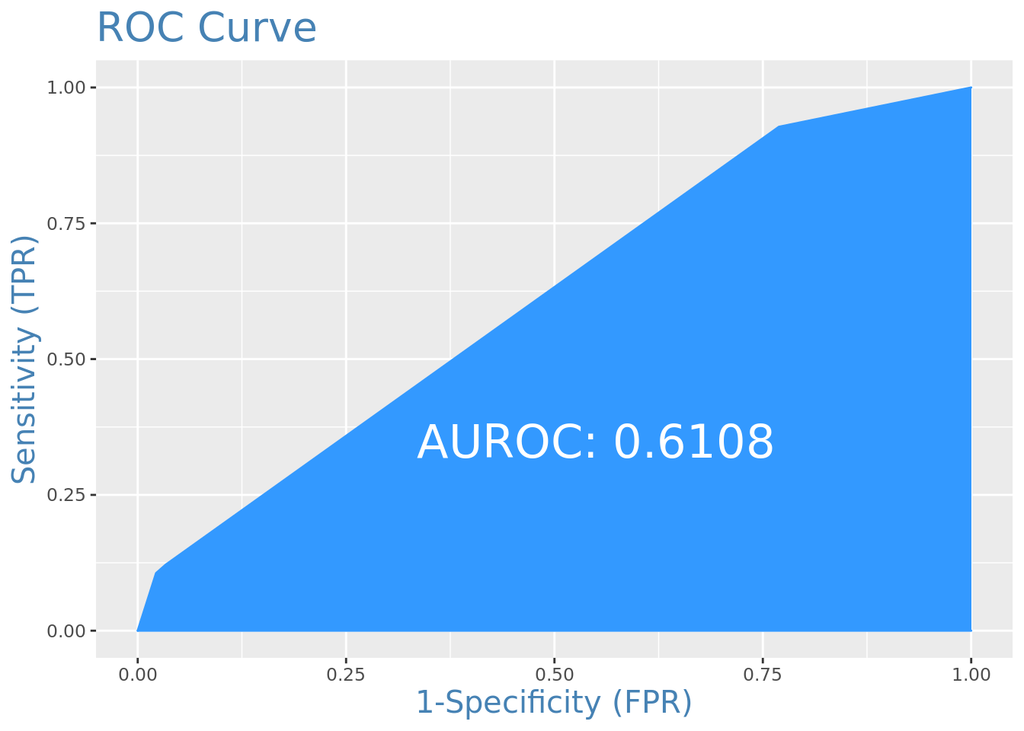

```r
plotROC(testData$race_ethnic, predicted)
```

Now, let’s check our ROC (i.e. Receiver Operating Characteristics Curve traces the percentage of true positives accurately predicted by a given logit model as the prediction probability cutoff is lowered from 1 to 0). A good model is closer to 1 and anything around 0.5 suggests the model is no better than chance. As you can see, our model is not very good at predicting the use of race/ethnicity. Thus, while our results might be interesting, we cannot have much confidence that (these) funding mechanisms really help explain the outcome.

```r
# Concordance
Concordance(testData$race_ethnic, predicted)
```

```
## $Concordance
## [1] 0.3138226
##
## $Discordance
## [1] 0.6861774
##
## $Tied
## [1] 0
##
## $Pairs
## [1] 4481073
```

```r
# sensitivity and specificity
sensitivity(testData$race_ethnic, predicted, threshold = optCutOff)
```

```
## [1] 0.1059432
```

```r
specificity(testData$race_ethnic, predicted, threshold = optCutOff)
```

```
## [1] 0.9779774
```

```r
# Confusion Matrix
#confusionMatrix(testData$race_ethnic, predicted, threshold = optCutOff)
```

When we look at the concordance, which is closer to 1 than 0 in good models, we see again this model is poor at predicting our outcome. Furthermore, the sensitivity and specificity show that the model is not good at predicting the 1’s (actuals) in the model despite being decent at predicting the 0’s (actuals).

# Step 6: Sex/Gender Model

Now, let’s repeat that same process with sex/gender as the outcome.

```r
# Create Training Data
input_ones <- funding_data[which(funding_data$sex_gender == 1), ]
input_zeros <- funding_data[which(funding_data$sex_gender == 0), ]
set.seed(100)
input_ones_training_rows <- sample(1:nrow(input_ones), 0.7*nrow(input_ones))
input_zeros_training_rows <- sample(1:nrow(input_zeros), 0.7*nrow(input_ones))
training_ones <- input_ones[input_ones_training_rows, ]
training_zeros <- input_zeros[input_zeros_training_rows, ]
trainingData <- rbind(training_ones, training_zeros)

# Create Test Data
test_ones <- input_ones[-input_ones_training_rows, ]
test_zeros <- input_zeros[-input_zeros_training_rows, ]
testData <- rbind(test_ones, test_zeros)
table(trainingData$sex_gender)
```

```
##
##    0    1
## 1027 1027
```

Let’s run this model and see what we get.

```r
gender_model <- glm(sex_gender ~ nih  + hhs + euro + uk  + foundation + other,
                  family = binomial(link = "logit"), data = testData)
summary(gender_model)
```

```
##
## Call:
## glm(formula = sex_gender ~ nih + hhs + euro + uk + foundation +
##     other, family = binomial(link = "logit"), data = testData)
##
## Deviance Residuals:
##     Min       1Q   Median       3Q      Max
## -0.3554  -0.2776  -0.2776  -0.2776   3.0793
##
## Coefficients:
##             Estimate Std. Error z value Pr(>|z|)
## (Intercept) -2.86866    0.21096 -13.598   <2e-16 ***
## nih         -0.41874    0.24580  -1.704   0.0885 .
## hhs          0.05027    0.31537   0.159   0.8734
## euro        -1.08119    0.72932  -1.482   0.1382
## uk          -0.51389    0.24171  -2.126   0.0335 *
## foundation  -0.35655    0.20705  -1.722   0.0851 .
## other        0.08813    0.28512   0.309   0.7573
## ---
## Signif. codes:  0 '***' 0.001 '**' 0.01 '*' 0.05 '.' 0.1 ' ' 1
##
## (Dispersion parameter for binomial family taken to be 1)
##
##     Null deviance: 3757.7  on 11713  degrees of freedom
## Residual deviance: 3743.6  on 11707  degrees of freedom
## AIC: 3757.6
##
## Number of Fisher Scoring iterations: 6
```

Here, we see that almost none of the funding sources have any impact on the use of sex/gender terminology.

```r
car::vif(gender_model)
```

```
##        nih        hhs       euro         uk foundation      other
##   4.344435   6.125965   1.041635   1.584508   1.574490   1.537222
```

Let’s check the validity of the model. HHS could have some multicolinearity.

```r
predicted <- plogis(predict(gender_model, testData))
optCutOff <- optimalCutoff(testData$sex_gender, predicted)[1]
misClassError(testData$sex_gender, predicted, threshold = optCutOff)
```

```
## [1] 0.0379
```

Our misclassification error (i.e. the percentage mismatch of predicted vs actuals) is low.

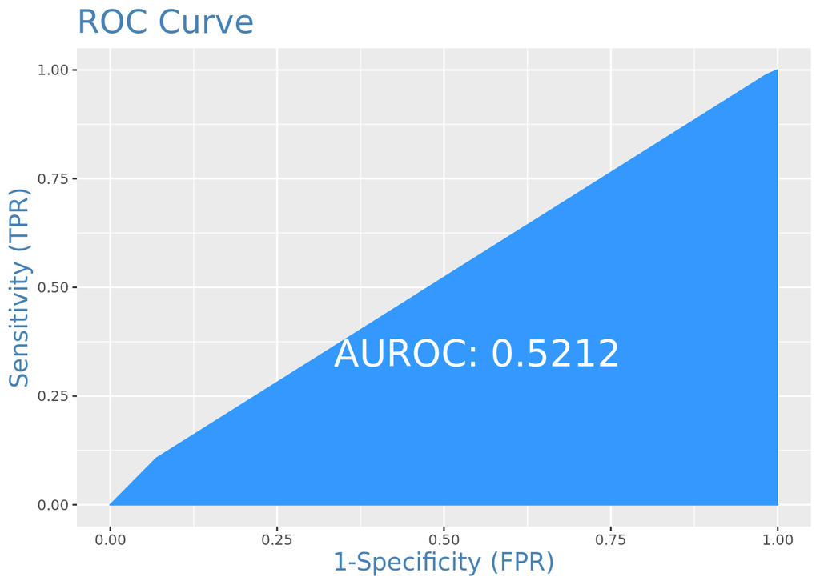

```r
plotROC(testData$sex_gender, predicted)
```

ROC suggests that this is a useless model.

```r
# Concordance
Concordance(testData$sex_gender, predicted)
```

```
## $Concordance
## [1] 0.2560023
##
## $Discordance
## [1] 0.7439977
##
## $Tied
## [1] 0
##
## $Pairs
## [1] 4971393
```

```r
# sensitivity and specificity
sensitivity(testData$sex_gender, predicted, threshold = optCutOff)
```

```
## [1] 0
```

```r
specificity(testData$sex_gender, predicted, threshold = optCutOff)
```

```
## [1] 0.9997339
```

```r
# Confusion Matrix
#confusionMatrix(testData$race_ethnic, predicted, threshold = optCutOff)
```

# Step 7: All Population Terms Model

Now, let’s repeat that same process with all population terms as the outcome.

```r
# Create Training Data
input_ones <- funding_data[which(funding_data$all_pop == 1), ]
input_zeros <- funding_data[which(funding_data$all_pop == 0), ]
set.seed(100)
input_ones_training_rows <- sample(1:nrow(input_ones), 0.7*nrow(input_ones))
input_zeros_training_rows <- sample(1:nrow(input_zeros), 0.7*nrow(input_ones))
training_ones <- input_ones[input_ones_training_rows, ]
training_zeros <- input_zeros[input_zeros_training_rows, ]
trainingData <- rbind(training_ones, training_zeros)

# Create Test Data
test_ones <- input_ones[-input_ones_training_rows, ]
test_zeros <- input_zeros[-input_zeros_training_rows, ]
testData <- rbind(test_ones, test_zeros)
table(trainingData$all_pop)
```

```
##
##    0    1
## 3283 3283
```

Let’s run this model and see what we get.

```r
allpop_model <- glm(all_pop ~ nih  + hhs + euro + uk  + foundation + other,
                  family = binomial(link = "logit"), data = testData)
summary(allpop_model)
```

```
##
## Call:
## glm(formula = all_pop ~ nih + hhs + euro + uk + foundation +
##     other, family = binomial(link = "logit"), data = testData)
##
## Deviance Residuals:
##     Min       1Q   Median       3Q      Max
## -0.9312  -0.6408  -0.6408  -0.6111   2.0810
##
## Coefficients:
##             Estimate Std. Error z value Pr(>|z|)
## (Intercept) -1.10117    0.11959  -9.208  < 2e-16 ***
## nih         -0.69394    0.16826  -4.124 3.72e-05 ***
## hhs          0.31636    0.20113   1.573 0.115736
## euro        -0.21137    0.30778  -0.687 0.492236
## uk          -0.48203    0.13367  -3.606 0.000311 ***
## foundation   0.17381    0.11027   1.576 0.114981
## other       -0.08251    0.17964  -0.459 0.645990
## ---
## Signif. codes:  0 '***' 0.001 '**' 0.01 '*' 0.05 '.' 0.1 ' ' 1
##
## (Dispersion parameter for binomial family taken to be 1)
##
##     Null deviance: 7117.0  on 7201  degrees of freedom
## Residual deviance: 7074.2  on 7195  degrees of freedom
## AIC: 7088.2
##
## Number of Fisher Scoring iterations: 4
```

```r
car::vif(allpop_model)
```

```
##        nih        hhs       euro         uk foundation      other
##   5.662729   7.271582   1.055031   1.554705   1.557445   1.366423
```

Let’s check the validity of the model. NIH and HHS could have some multicolinearity.

```r
predicted <- plogis(predict(allpop_model, testData))
optCutOff <- optimalCutoff(testData$all_pop, predicted)[1]
misClassError(testData$all_pop, predicted, threshold = optCutOff)
```

```
## [1] 0.1959
```

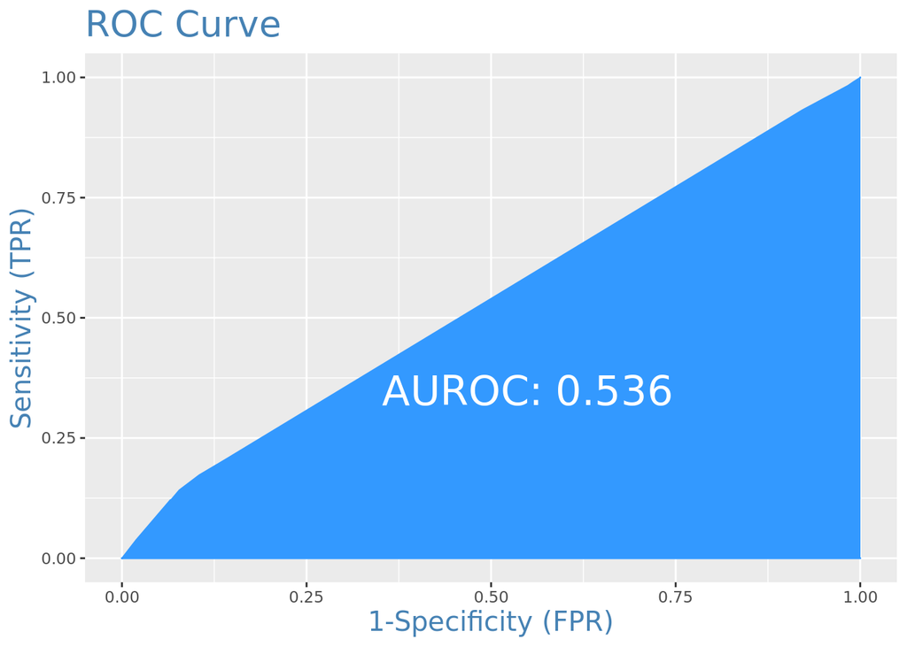

```r
plotROC(testData$all_pop, predicted)
```

ROC suggests that this is a useless model.

```r
# Concordance
Concordance(testData$all_pop, predicted)
```

```
## $Concordance
## [1] 0.2630695
##
## $Discordance
## [1] 0.7369305
##
## $Tied
## [1] 0
##
## $Pairs
## [1] 8157952
```

```r
# sensitivity and specificity
sensitivity(testData$all_pop, predicted, threshold = optCutOff)
```

```
## [1] 0
```

```r
specificity(testData$all_pop, predicted, threshold = optCutOff)
```

```
## [1] 0.9994822
```

```r
# Confusion Matrix
#confusionMatrix(testData$race_ethnic, predicted, threshold = optCutOff)
```

```r
#References
#http://r-statistics.co/Logistic-Regression-With-R.html
#http://www.sthda.com/english/articles/39-regression-model-diagnostics/160-multicollinearity-essentials-and-vif-in-r/
```